# My SpotifyR report

Author

Esther

## Taylor Swift

Are you ready for it?

[video not shown]

### Why Taylor Swift?

Why not?

There is a vast array of songs to choose from…

Also the Eras tour (which I have not been to 😔)

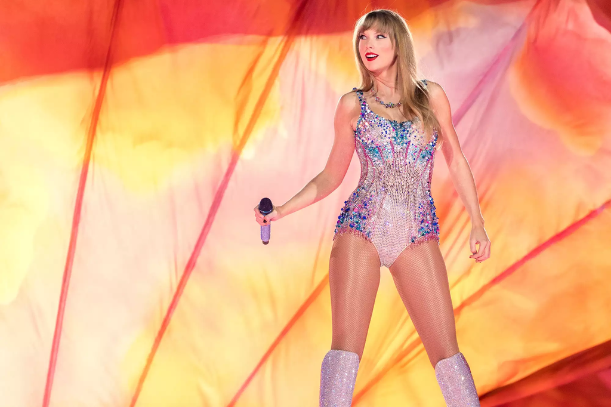

*“Welcome to the Eras Tour!” -* Taylor Swift

### Fun fact

This February Taylor had over 87 million monthly listeners on Spotify 🤯. Making her the 10th most listened to artist on Spotify this month.

### My favourites

#### Favourite album

At the moment either

[figure not shown]

or

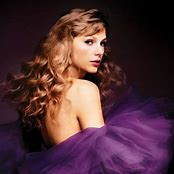

But this changes per day :)

#### Favourite bridge

My current favourite bridge is in the song “All too Well”:

Well maybe we got lost in translation  
Maybe I asked for too much  
But maybe this thing was a masterpiece  
’Til you tore it all up  
Running scared, I was there I remember it all too well And you call me up again just to break me like a promise  
So casually cruel in the name of being honest  
I’m a crumpled up piece of paper lying here  
’Cause I remember it all, all, all...

## Data analysis

### Data source

A quick preview of what the dataset looks like:

| artist_name | track_name | track_number | album_name | album_release_year | album_release_date | valence | energy | danceability | loudness | tempo | speechiness | instrumentalness | liveness | key_name | mode_name | key_mode | duration_ms |
| --- | --- | --- | --- | --- | --- | --- | --- | --- | --- | --- | --- | --- | --- | --- | --- | --- | --- |
| Taylor Swift | Welcome To New York | 22 | reputation Stadium Tour Surprise Song Playlist | 2017 | 2017-11-09 | 0.66 | 0.63 | 0.79 | -4.76 | 116.99 | 0.03 | 0 | 0.30 | G | major | G major | 212600 |
| Taylor Swift | Snow On The Beach (feat. Lana Del Rey) | 4 | Midnights (The Til Dawn Edition) | 2023 | 2023-05-26 | 0.17 | 0.33 | 0.65 | -13.53 | 110.01 | 0.04 | 0 | 0.12 | A | major | A major | 256124 |
| Taylor Swift | False God | 13 | Lover | 2019 | 2019-08-23 | 0.35 | 0.32 | 0.74 | -10.86 | 79.97 | 0.24 | 0 | 0.11 | B | minor | B minor | 200306 |
| Taylor Swift | champagne problems | 2 | evermore | 2020 | 2020-12-11 | 0.32 | 0.24 | 0.46 | -12.08 | 171.32 | 0.04 | 0 | 0.11 | C | major | C major | 244000 |
| Taylor Swift | Our Song - International Mix | 14 | Fearless (International Version) | 2008 | 2008-11-11 | 0.66 | 0.70 | 0.52 | -4.83 | 177.94 | 0.03 | 0 | 0.35 | D | major | D major | 199933 |

```
[1] "character"
```

### Data preparation

The following code was run to prepare the dataset for analysis.

```r
#removing duplicates
df <- df %>% distinct(track_name, .keep_all = TRUE)

# Filtering to only include Taylor's version songs from re-recorded albums
library(stringr)

albums <- c("Midnights", "evermore", "folklore", "Lover", "reputation", "Taylor Swift", "Taylor's Version")
pattern <- paste(albums, collapse = "|")

Taylor_version <- df %>%
  filter(str_detect(album_name, pattern) & !str_detect(album_name, "^Taylor's Version"))

#filtering out other 'playlists'
Taylor_version <- Taylor_version %>% filter(!grepl("Surprise Song", album_name))
```

### Album analysis

As Taylor Swift has 12 albums (not including re-records, special editions, etcetera) and owns an incredibly large amount of songs, it might be interesting to see how the energy levels and loudness (dB) of her albums has varied throughout her career.

We might expect high energy songs to be louder as well… but lets see!

#### Energy

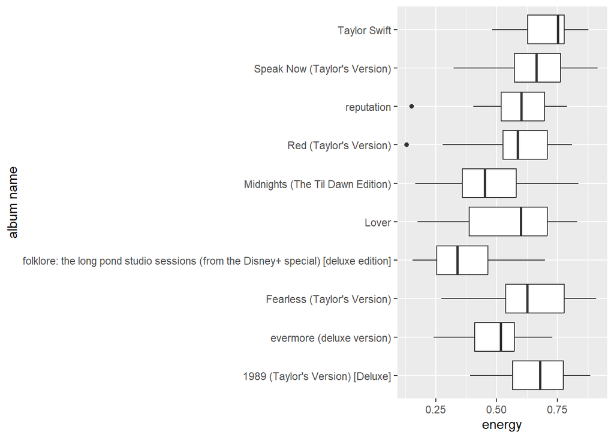

This boxplot shows that Taylor’s first album ‘Taylor Swift’ and her album1989 have the highest amount of energy. Folklore is by far the least energetic, but this might be due to the version of Folklore this dataset uses.

So what are her three most energetic songs?

| track_name | album_name | energy |
| --- | --- | --- |
| Haunted (Taylor’s Version) | Speak Now (Taylor’s Version) | 0.92 |
| Tell Me Why (Taylor’s Version) | Fearless (Taylor’s Version) | 0.91 |
| Better Than Revenge (Taylor’s Version) | Speak Now (Taylor’s Version) | 0.88 |
| Out Of The Woods (Taylor’s Version) | 1989 (Taylor’s Version) [Deluxe] | 0.88 |

#### Loudness

The following boxplot shows how ‘loud’ Taylor’s albums generally are. Loudness in the dataset is measured in decibels (dB). In music the reference point for decibels is 0. At this 0 point the sound will be so loud that the music will be distorted. Therefore, the more negative the loudness, the ‘softer’ the music.

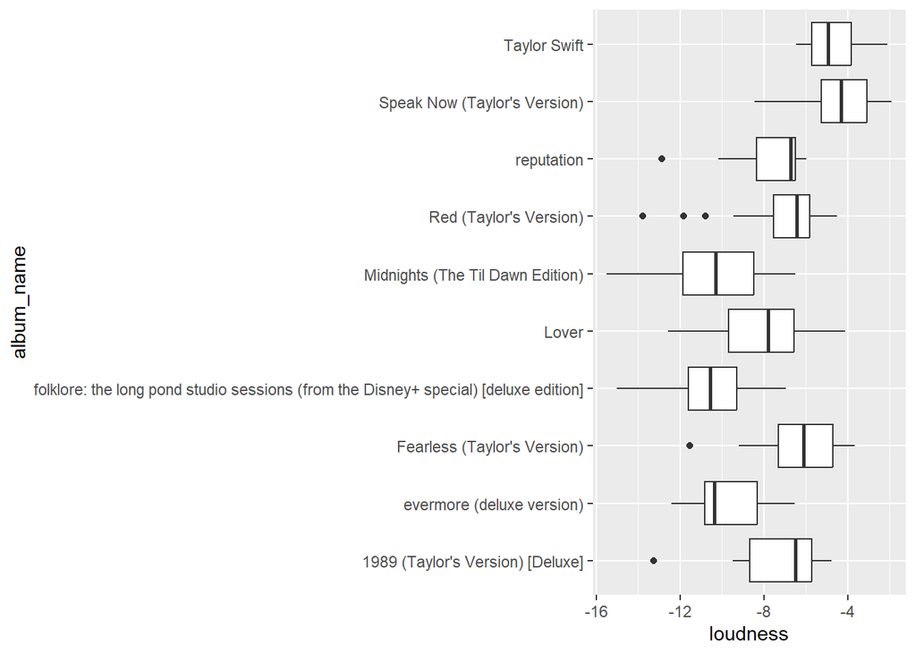

In the boxplot can be seen that Taylor’s loudest albums are ‘Taylor Swift’ and ‘Speak Now’. ‘Midnights’, ‘Folklore’ and ‘Evermore’ are on the quieter side.

What are her loudest songs?

| track_name | album_name | loudness |
| --- | --- | --- |
| Haunted (Taylor’s Version) | Speak Now (Taylor’s Version) | -1.91 |
| Picture To Burn | Taylor Swift | -2.10 |
| Sparks Fly (Taylor’s Version) | Speak Now (Taylor’s Version) | -2.35 |

#### Are energetic songs louder?

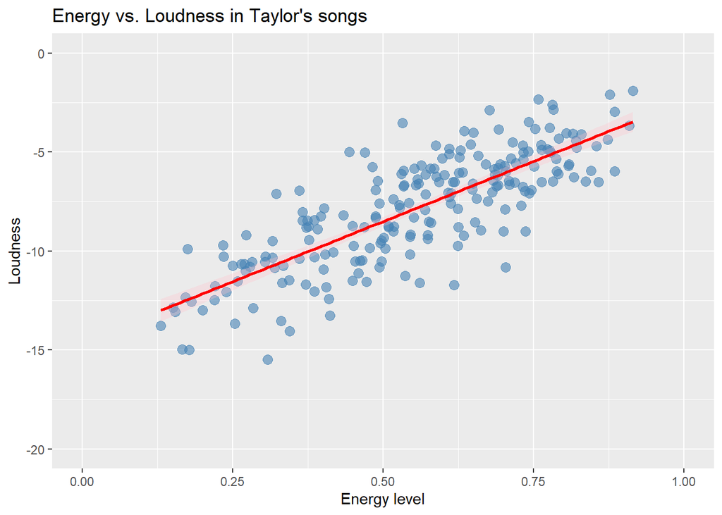

Based on this graph, it seems as though the higher the energy level in Taylor’s songs, the louder (dB) her songs are. It could be argued that Taylor purposefully chooses to increase loudness while recording energetic songs, to achieve these higher levels of energy.

Does she have albums that are generally louder and more energetic than her other albums?

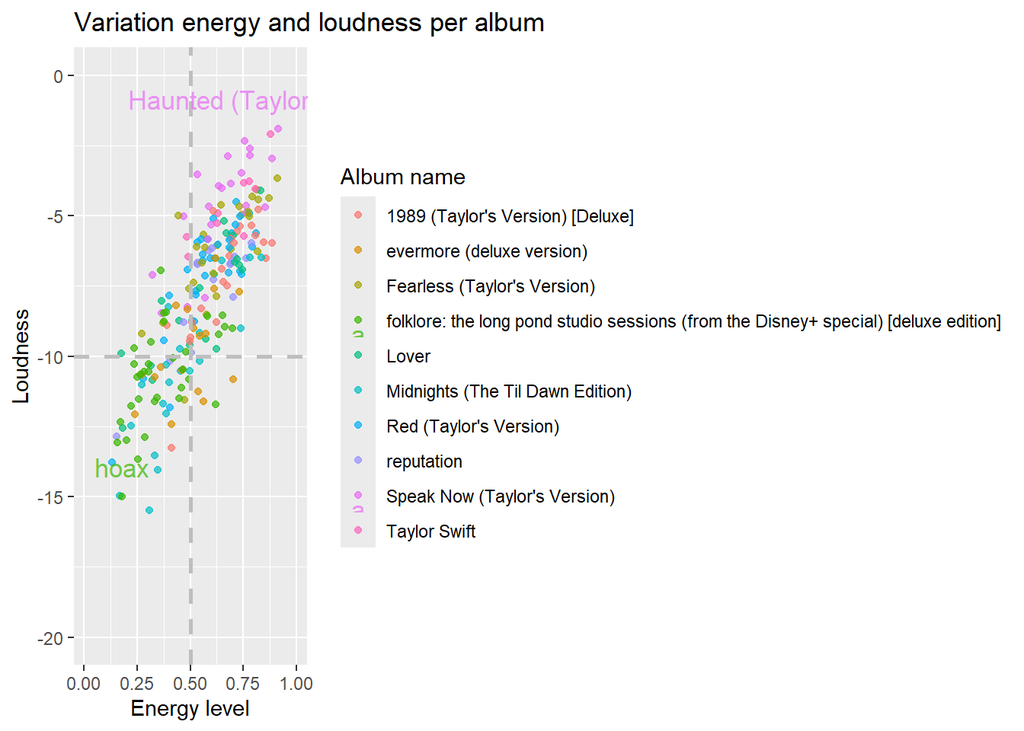

It looks like Reputation, Red, Speak Now, Taylor Swift, 1989, Fearless and Lover are generally more loud and energetic. Folklore and Midnights on the other hand are calmer and quieter.

As we’ve seen Taylor’s loudest and most energetic song is “Haunted”.

What do you think of the song? Does this combination make it sound angry/aggressive?

[video not shown]